# Workshop - OECD data using API in R

HealthIntelAct Training Week - Aalborg

l.boerty@rn.dk | laboni@dcm.aau.dk

Assistant professor - Center for Danish Health Services Research

2026-10-07

## About me

**Background**

- Economics (cand.oecon)
- PhD (epidemiology and biostatistics)

**Interests**

- Data visualization, Statistics and epidemiology
- Health economics
- R/SQL/SAS

**Research**

- Observational research (registry data)
- Cancer (hematology/oncology)
- Collaboration with pharma industry

## Agenda today

- Reproducible research
- OECD API in R
- Life expectancy in OECD countries
- Healthcare funding in OECD countries
- Combination
- Wrap-up

please go to dxforecast.aau.dk for slides (you will need to copy code)

## Reproducible research

**Non-reproducible workflow**

- Download data as file from a website
- Unstructured data handeling: copy-paste, delete outliers, comments in data
- Unstructured analysis: Results from mix of sources
- Hard to repeat analysis when data are updated, and to check for errors

**Examples:**

Rainhart & Rogoff - Growth in a Time of Debt (2010)

The replication crisis

**Reproducible workflow**

- Data are fetched directly from the source (e.g. API)
  - Raw data is not edited
- Every step is documented in code
- Update analysis by re-running the script
- Easy to share, review and reuse

Unfortunately incentives doesn’t always align

**Important initiatives:**

- Open source tools (R, Python, Julia, LaTex, etc.)
- Non-commercial repositories/directories (Zenodo, arXiv, ORCID)

# What is an API?

## API

An **A**pplication **P**rogramming **I**nterface lets code ask a server for data directly - no clicking in a web page.

Many institutions issue public facing API

- OECD
- Statistics Denmark
- DMI/CVR/DAWA
- EuroStat
- IMF/WB
- Stock exchanges

Increase in use of API keys in public api - to manage access

- AWS/Azure/Google cloud

## OECD data explorer

**What do you think the lift expectancy for a male in Denmark, US and Mexico was in 2015 (and why?)**

[OECD Data Explorer](https://data-explorer.oecd.org/) See if you can find life expectancy in Denmark in 2015 for a male

Health > Health status > Life expectancy Y0 > DNK: 78.8 years, USA: 76.3, MEX: 72.4

What does life expectancy from birth measure?

## OECD API in R

We will be using the unofficial R package OECD [Github](https://github.com/expersso/oecd)

```r
#install.packages("pak")
#install.packages("tidyverse")

library(tidyverse)
library(pak)
pak("expersso/OECD")
library(OECD)
```

The server returns the data, and the R `OECD` package turns it into a `data.frame`. The OECD uses the **SDMX** standard, so all datasets are organised in the same way: *dimensions* (e.g. country, age, sex) and *observations* (the value).

## Your turn - try the API!

```r
life <- get_dataset(dataset = "OECD.ELS.HD,DSD_HEALTH_STAT@DF_LE,1.1")
```

**Tasks:**

1. Find out what was the expected remaining life for a 65 year old male in DNK, USA, MEX in 2015
2. Plot the life expectancy af a 0, 40, 60, 65 and 80 year old in DNK in 2015
3. Stratify by country

## Task 1.1

```r
life |>
  filter(REF_AREA    == "DNK",
         MEASURE     == "LFEXP",
         SEX         == "M",
         AGE         == "Y65",
         TIME_PERIOD == 2015) |>
  select(ObsValue)
```

```
# A tibble: 1 × 1
  ObsValue
  <chr>
1 17.9
```

```r
life |>
  filter(REF_AREA    %in% c("DNK","USA","MEX"),
         MEASURE     == "LFEXP",
         SEX         == "M",
         AGE         %in% c("Y0","Y65"),
         TIME_PERIOD == 2015) |>
  select(ObsValue, REF_AREA, AGE) |>
  pivot_wider(names_from = REF_AREA,values_from = ObsValue)
```

```
# A tibble: 2 × 4
  AGE   MEX   USA   DNK
  <chr> <chr> <chr> <chr>
1 Y0    72.4  76.3  78.8
2 Y65   17.4  18    17.9
```

## Task 1.2

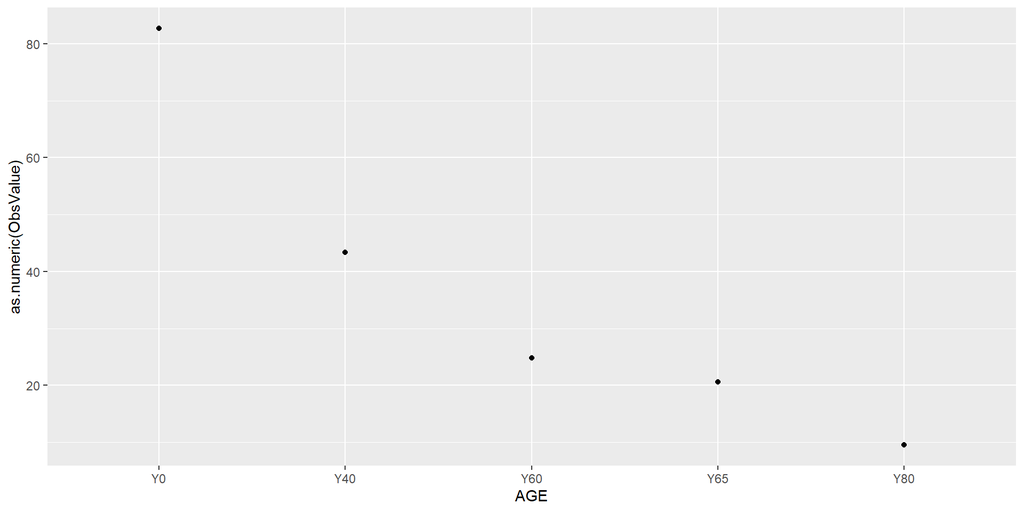

```r
life |>
  filter(REF_AREA    == "DNK",
         MEASURE     == "LFEXP",
         SEX         == "F",
         TIME_PERIOD == 2015) |>
  ggplot(aes(x = AGE, y = as.numeric(ObsValue))) + geom_point()
```

## Task 1.3

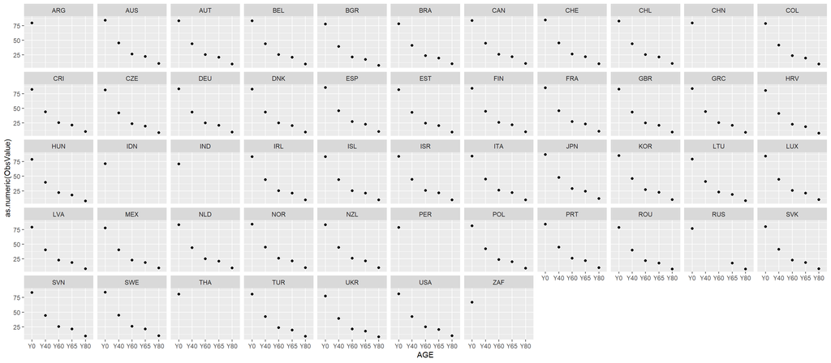

```r
life |>
  filter(MEASURE     == "LFEXP",
         SEX         == "F",
         TIME_PERIOD == 2015) |>
  ggplot(aes(x = AGE, y = as.numeric(ObsValue))) + geom_point() + facet_wrap(~REF_AREA, nrow=5)
```

# Life expectancy in OECD countries

## Example - stratification by sex

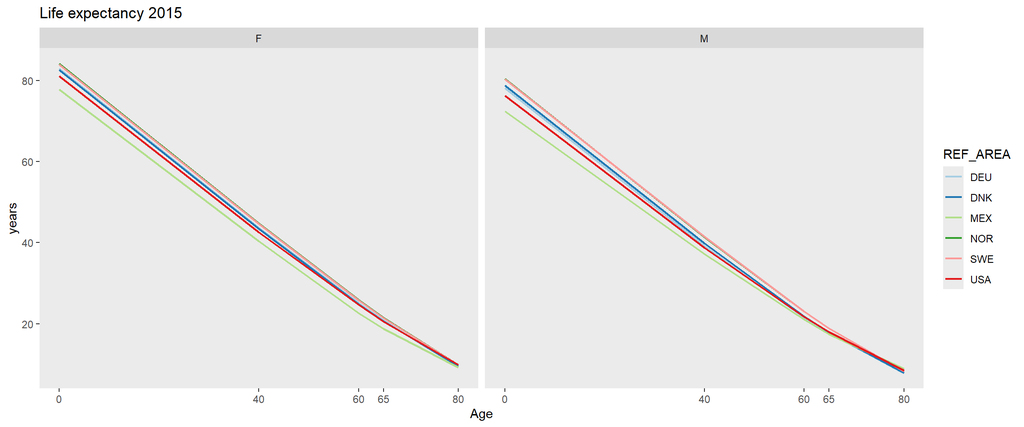

```r
life2 <- life |>
  select(REF_AREA, MEASURE, AGE, TIME_PERIOD, SEX, ObsValue) |>
  filter(TIME_PERIOD == 2015,
         MEASURE == "LFEXP",
         REF_AREA %in% c("MEX","SWE","NOR","DNK","DEU","USA")) |>
  mutate(AGE2 = parse_number(AGE),
         SEX2 = case_when(SEX=="M"~"Male",
                          SEX=="F"~"Female",
                          SEX=="_T"~"Total"),
         ObsValue = as.numeric(ObsValue))

life2 |> filter(SEX!="_T") |>
  ggplot(aes(x=AGE2, y=ObsValue, color=REF_AREA)) +
  geom_line(linewidth = 0.8) +
  scale_x_continuous(breaks=c(0,40,60,65,80)) +
  scale_color_brewer(palette="Paired")+
  facet_wrap(~SEX) +
  theme(panel.grid = element_blank()) +
  labs(title="Life expectancy 2015", y="years",x="Age")
```

## Example - stratification by country

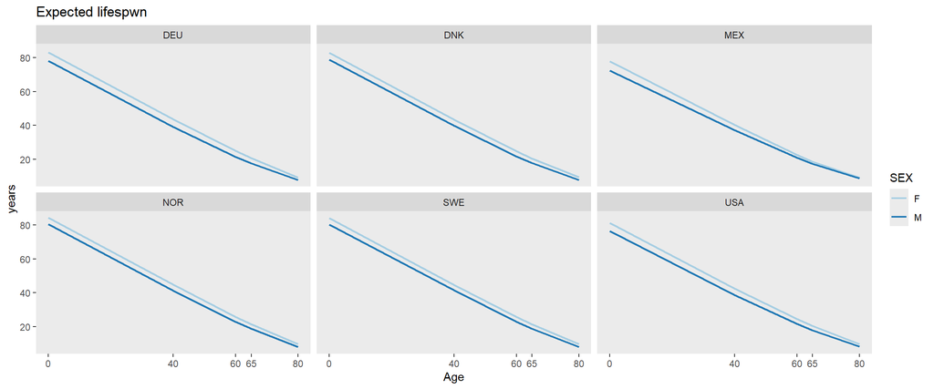

```r
life2 |> filter(SEX!="_T") |>
  ggplot(aes(x=AGE2, y=ObsValue, color=SEX)) +
  geom_line(linewidth = 0.8) +
  scale_x_continuous(breaks=c(0,40,60,65,80)) +
  scale_color_brewer(palette="Paired") +
  facet_wrap(~REF_AREA) +
  theme(panel.grid = element_blank()) +
  labs(title="Expected lifespwn", y="years",x="Age")
```

## Example - ratio male-female

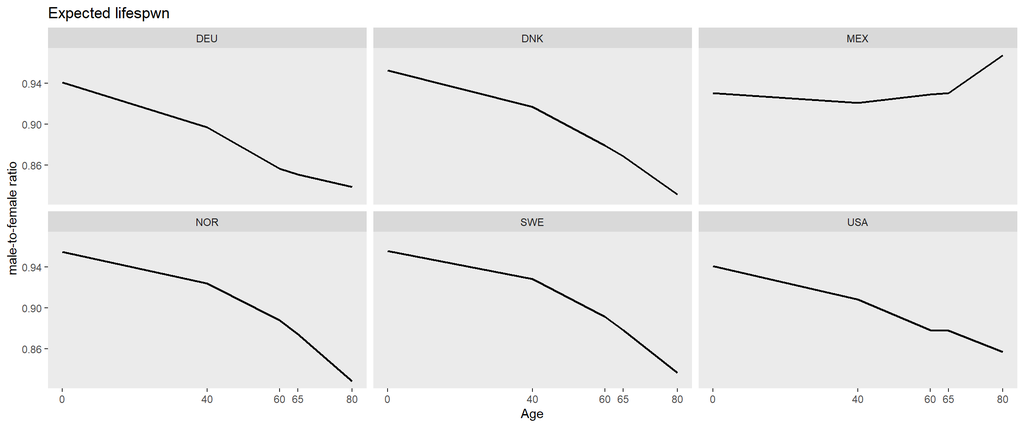

```r
life2 |> filter(SEX!="_T") |>
  select(-SEX) |>
  pivot_wider(names_from = SEX2, values_from = ObsValue) |>
  mutate(rate = Male/(Female)) |>
  ggplot(aes(x=AGE2, y=rate)) +
  geom_line(linewidth = 0.8) +
  scale_x_continuous(breaks=c(0,40,60,65,80)) +
  scale_color_brewer(palette="Paired")+
  facet_wrap(~REF_AREA) +
  theme(panel.grid = element_blank()) +
  labs(title="Expected lifespwn", y="male-to-female ratio",x="Age")
```

## Example - ratio male-female through time

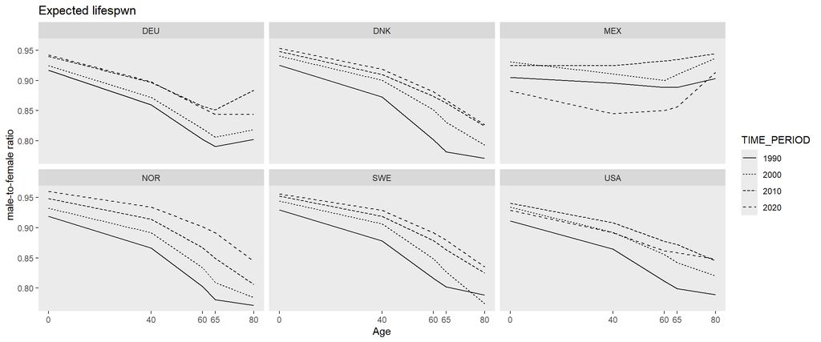

```r
life3 <- life |>
  select(REF_AREA, MEASURE, AGE, TIME_PERIOD, SEX, ObsValue) |>
  filter(TIME_PERIOD %in% c(1990,2000,2010,2020),
         MEASURE == "LFEXP",
         REF_AREA %in% c("MEX","SWE","NOR","DNK","DEU","USA")) |>
  mutate(AGE2 = parse_number(AGE),
         SEX2 = case_when(SEX=="M"~"Male",
                          SEX=="F"~"Female",
                          SEX=="_T"~"Total"),
         ObsValue = as.numeric(ObsValue))

life3 |> filter(SEX!="_T") |>
  select(-SEX) |>
  pivot_wider(names_from = SEX2, values_from = ObsValue) |>
  mutate(rate = Male/(Female)) |>
  ggplot(aes(x=AGE2, y=rate, linetype=TIME_PERIOD)) +
  geom_line(linewidth = 0.5) +
  scale_x_continuous(breaks=c(0,40,60,65,80)) +
  scale_color_brewer(palette="Paired")+
  facet_wrap(~REF_AREA) +
  theme(panel.grid = element_blank()) +
  labs(title="Expected lifespwn", y="male-to-female ratio",x="Age")
```

## Example - ratio male-female through time

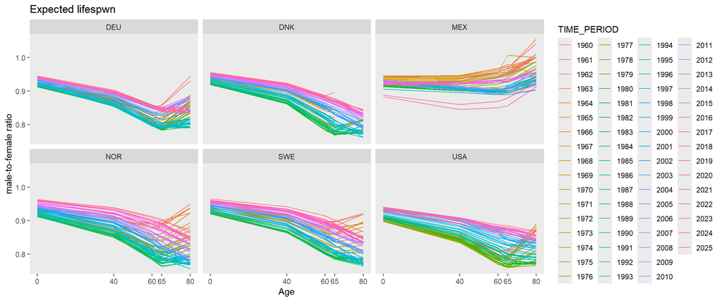

```r
life3 <- life |>
  select(REF_AREA, MEASURE, AGE, TIME_PERIOD, SEX, ObsValue) |>
  filter(MEASURE == "LFEXP",
         REF_AREA %in% c("MEX","SWE","NOR","DNK","DEU","USA")) |>
  mutate(AGE2 = parse_number(AGE),
         SEX2 = case_when(SEX=="M"~"Male",
                          SEX=="F"~"Female",
                          SEX=="_T"~"Total"),
         ObsValue = as.numeric(ObsValue))

life3 |> filter(SEX!="_T") |>
  select(-SEX) |>
  pivot_wider(names_from = SEX2, values_from = ObsValue) |>
  mutate(rate = Male/(Female)) |>
  ggplot(aes(x=AGE2, y=rate, color=TIME_PERIOD)) +
  geom_line(linewidth = 0.5) +
  scale_x_continuous(breaks=c(0,40,60,65,80)) +
  facet_wrap(~REF_AREA) +
  theme(panel.grid = element_blank()) +
  labs(title="Expected lifespwn", y="male-to-female ratio",x="Age")
```

## Example - expected lifetime through time

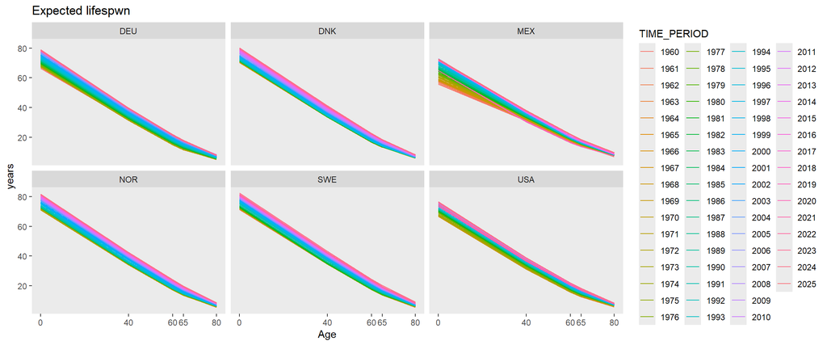

```r
life3 |> filter(SEX=="M") |>
  ggplot(aes(x=AGE2, y=ObsValue, color=TIME_PERIOD)) +
  geom_line(linewidth = 0.5) +
  scale_x_continuous(breaks=c(0,40,60,65,80)) +
  facet_wrap(~REF_AREA) +
  theme(panel.grid = element_blank()) +
  labs(title="Expected lifespwn", y="years",x="Age")
```

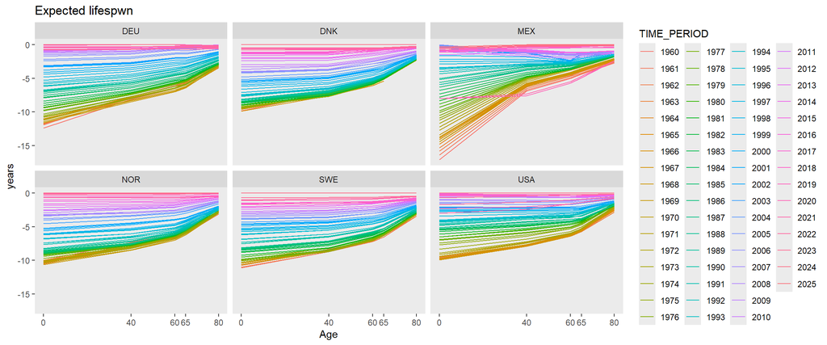

```r
life3 |> filter(SEX=="M") |>
  group_by(REF_AREA, AGE) |>
  mutate(mm = max(ObsValue)) |>
  ungroup() |>
  mutate(ObsValue = ObsValue-mm) |>
  ggplot(aes(x=AGE2, y=ObsValue, color=TIME_PERIOD)) +
  geom_line(linewidth = 0.5) +
  scale_x_continuous(breaks=c(0,40,60,65,80)) +
  facet_wrap(~REF_AREA) +
  theme(panel.grid = element_blank()) +
  labs(title="Expected lifespwn", y="years",x="Age")
```

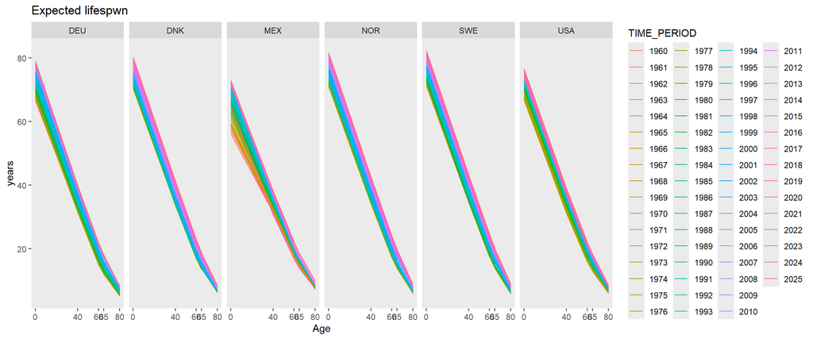

```r
life3 |> filter(SEX=="M") |>
  ggplot(aes(x=AGE2, y=ObsValue, color=TIME_PERIOD)) +
  geom_line(linewidth = 0.5) +
  scale_x_continuous(breaks=c(0,40,60,65,80)) +
  facet_wrap(~REF_AREA, nrow=1) +
  theme(panel.grid = element_blank()) +
  labs(title="Expected lifespwn", y="years",x="Age")
```

# Healthcare funcing in OECD countries

## New API request - healthcare funding

```r
funding <- get_dataset(dataset = "OECD.ELS.HD,DSD_SHA@DF_SHA",
                  filter = "SWE+NLD+GBR+USA+DEU+DNK+FRA.A.EXP_HEALTH.PT_B1GQ.HF122+HF121+HF3+HF2+HF11.._T._T._T..._Z")
```

Copy the code and do the following tasks.

**Tasks:**

1. Find out what programs (FINANCING_SCHEMES) financed danish healthcare in 2015
2. Plot the healthcare funcing for Denmark through time
3. Stratify by country

| code | Financing Scheme |
| --- | --- |
| HF11 | Government schemes |
| HF121 | Social health insurance schemes |
| HF122 | Compulsory private insurance schemes |
| HF2 | Voluntary healthcare payment schemes |
| HF3 | Household out-of-pocket payment |

## Task 2.1

```r
funding |>
  filter(REF_AREA    == "DNK",
         TIME_PERIOD == 2015) |>
  select(FINANCING_SCHEME, ObsValue)
```

```
# A tibble: 3 × 2
  FINANCING_SCHEME ObsValue
  <chr>            <chr>
1 HF11             8.726
2 HF2              0.237
3 HF3              1.396
```

## Task 2.2

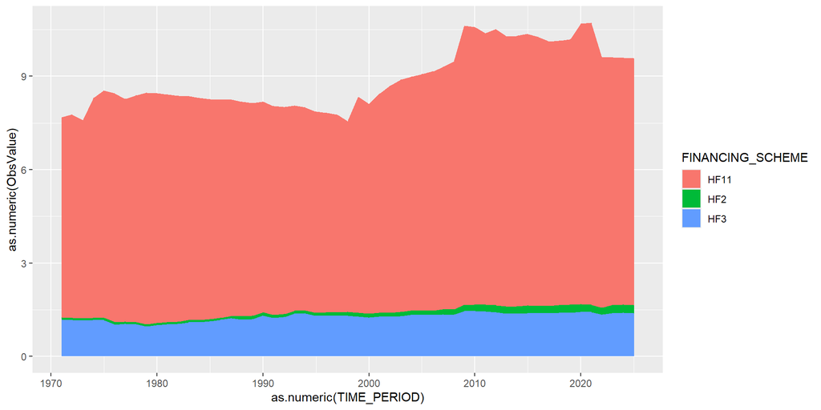

```r
funding |>
  filter(REF_AREA == "DNK") |>
  ggplot(aes(x=as.numeric(TIME_PERIOD), y=as.numeric(ObsValue), fill=FINANCING_SCHEME)) +
  geom_area()
```

## Task 2.3

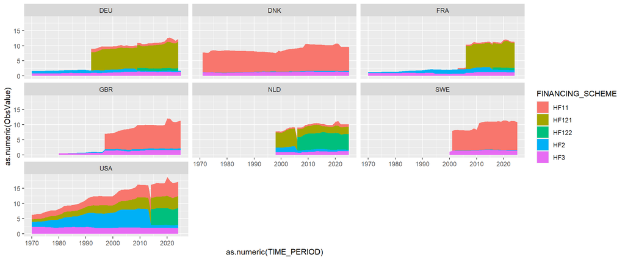

```r
funding |>
  ggplot(aes(x=as.numeric(TIME_PERIOD), y=as.numeric(ObsValue), fill=FINANCING_SCHEME)) +
  geom_area() + facet_wrap(~REF_AREA)
```

## Nice plot healthcare expenditures

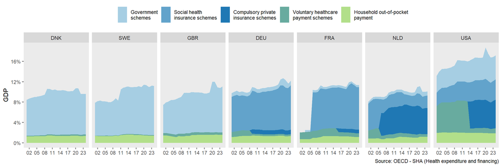

```r
plot <- funding |>
  mutate(obsTime = as.numeric(TIME_PERIOD)) |>
  mutate(ObsValue = as.numeric(ObsValue)) |>
  filter(between(obsTime, 2001, 2025)) |>
  mutate(date = as.Date(paste0(obsTime,"-01-01"))) |>
  select(date, ObsValue, FINANCING_SCHEME, REF_AREA) |>
  add_row(date = as.Date("2013-01-01"), ObsValue = 0, FINANCING_SCHEME = "HF122", REF_AREA = "USA") |>
  add_row(date = as.Date("2005-01-01"), ObsValue = 0, FINANCING_SCHEME = "HF122", REF_AREA = "NLD") |>
  add_row(date = as.Date("2015-01-01"), ObsValue = 0, FINANCING_SCHEME = "HF122", REF_AREA = "FRA") |>
  add_row(date = as.Date("2005-01-01"), ObsValue = 0, FINANCING_SCHEME = "HF121", REF_AREA = "FRA") |>
  add_row(date = as.Date("2008-01-01"), ObsValue = 0, FINANCING_SCHEME = "HF122", REF_AREA = "DEU") |>
  mutate(REF_AREA = fct_relevel(REF_AREA, "DNK","SWE","GBR")) |>
  ggplot(aes(date, ObsValue, fill = FINANCING_SCHEME)) +
  geom_area() +
  facet_wrap(~REF_AREA, nrow = 1) +
  scale_y_continuous(breaks = c(seq(0,20, by = 4)),
                     label = unit_format(unit = "%", sep = "", accuracy = 1)) +
  scale_fill_manual("",values = palblue(5),
                    labels = c("Government\nschemes",
                               "Social health\ninsurance schemes",
                               "Compulsory private\ninsurance schemes",
                               "Voluntary healthcare\npayment schemes",
                               "Household out-of-pocket\npayment")) +
  scale_x_date(breaks = seq(ymd("2002-01-01"), ymd("2023-01-01"), by = '3 years'),
               date_labels = "%y",
               limits = as.Date(c("2001-01-01","2024-01-01"))) +
  labs(title = NULL,
       caption = "Source: OECD - SHA (Health expenditure and financing)",
       x = NULL, y = "GDP") +
  theme(legend.key.height = unit(2,"line"),
        legend.key = element_blank(),
        legend.position = "top",
        panel.grid.major = element_blank(),
        panel.grid.minor = element_blank())

plot
```

- Healthcare is a superior good

# Combination healthcare expenditures and expected lifetime

## All ages

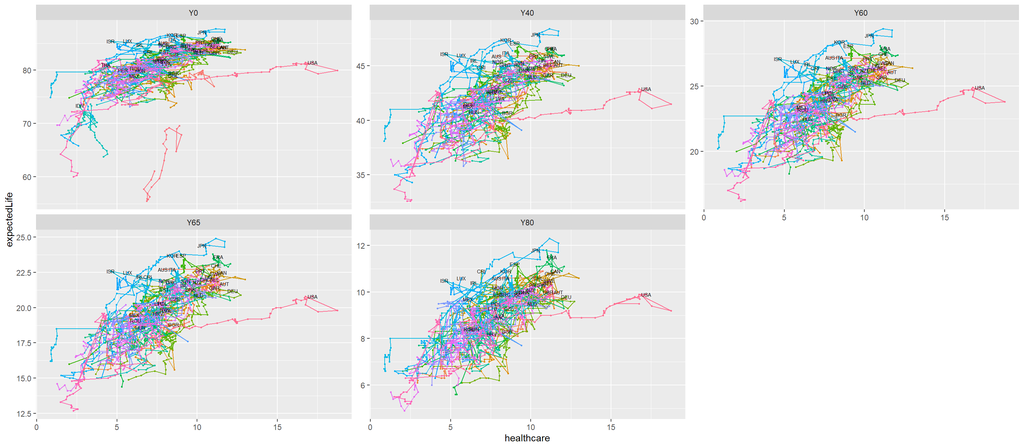

```r
fund <- get_dataset(dataset = "OECD.ELS.HD,DSD_SHA@DF_SHA",
                  filter = ".A.EXP_HEALTH.PT_B1GQ.HF1+HF2+HF3.._T._T._T..._Z") |>
  select(FINANCING_SCHEME, REF_AREA, TIME_PERIOD, ObsValue) |>
  group_by(TIME_PERIOD, REF_AREA) |>
  summarize(healthcare = sum(as.numeric(ObsValue), na.rm=T))

combined <- life |> filter(MEASURE == "LFEXP", SEX == "F") |>
  select(AGE, ObsValue, REF_AREA, TIME_PERIOD) |>
  left_join(fund) |>
  mutate(expectedLife = as.numeric(ObsValue),
         year=as.numeric(TIME_PERIOD)) |>
  filter(REF_AREA!="RUS", TIME_PERIOD<2025, !is.na(healthcare))

combined |>
  ggplot(aes(x=healthcare, y=expectedLife, color=REF_AREA)) +
  geom_point(size=0.5,show.legend = F) + facet_wrap(~AGE, scales="free_y") +
  geom_path(show.legend = F) +
  geom_text(data=combined |> filter(TIME_PERIOD==2024), color="black",size=2,aes(label=REF_AREA))
```

## Expected remaining lifetime 65 years

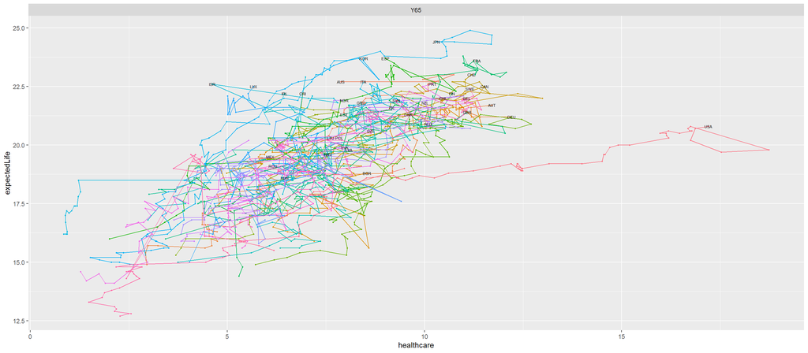

```r
combined |> filter(AGE == "Y65") |>
  ggplot(aes(x=healthcare, y=expectedLife, color=REF_AREA)) +
  geom_point(size=0.5,show.legend = F) + facet_wrap(~AGE, scales="free_y") +
  geom_path(show.legend = F) +
  geom_text(data=combined |> filter(TIME_PERIOD==2024,AGE == "Y65"), color="black",size=2,aes(label=REF_AREA))
```

## Expected remaining lifetime 65 years (country)

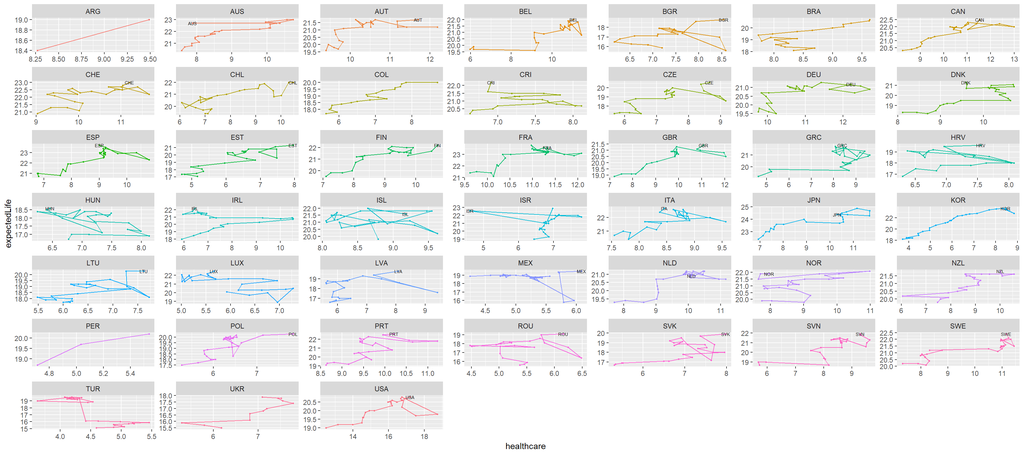

```r
combined |> filter(AGE == "Y65", year>1999) |>
  ggplot(aes(x=healthcare, y=expectedLife, color=REF_AREA)) +
  geom_point(size=0.5,show.legend = F) + facet_wrap(~REF_AREA, scales="free") +
  geom_path(show.legend = F)+
  geom_text(data=combined |> filter(TIME_PERIOD==2024,AGE == "Y65"), color="black",size=2,aes(label=REF_AREA))
```

```r
combined2 <- combined |> filter(AGE == "Y65") |>
  filter(REF_AREA %in% c("DNK","USA","SWE","MEX","GER","DEU","FRA","JPN","POL","ITA")) |>
  mutate(healthcare = if_else(REF_AREA=="ITA" & healthcare <4,NA,healthcare))

  combined2 |>
  ggplot(aes(x=healthcare, y=expectedLife, color=REF_AREA)) +
  geom_path(show.legend = F,size=0.7) +
  geom_point(size=1.2,show.legend = T, shape=21, fill="white",stroke = 1.3) +
  scale_y_continuous(breaks=seq(0,26,2),labels = scales::label_number(suffix = " years"))+
  scale_x_continuous(breaks=seq(0,26,2),labels = scales::label_number(suffix = "%"))+
    scale_color_brewer(palette="Paired")+
  geom_text(data=combined2 |> filter(TIME_PERIOD==2024,AGE == "Y65"), color="black",size=3,aes(label=REF_AREA,y=expectedLife+0.2)) +
  labs(title = "Healthcare spending vs. expected remaining lifetime at 65 1970 - 2024",
       caption = "Source: OECD - SHA (Health expenditure and financing) and LE (Life expectancy)",
       x = "Healthcare spending as fraction of GDP", y = "Expected remaining lifetime at 65",
       color="Country") +
  theme(legend.key = element_blank(),
        legend.position = "right",
        panel.grid.major = element_blank(),
        panel.grid.minor = element_blank())
```

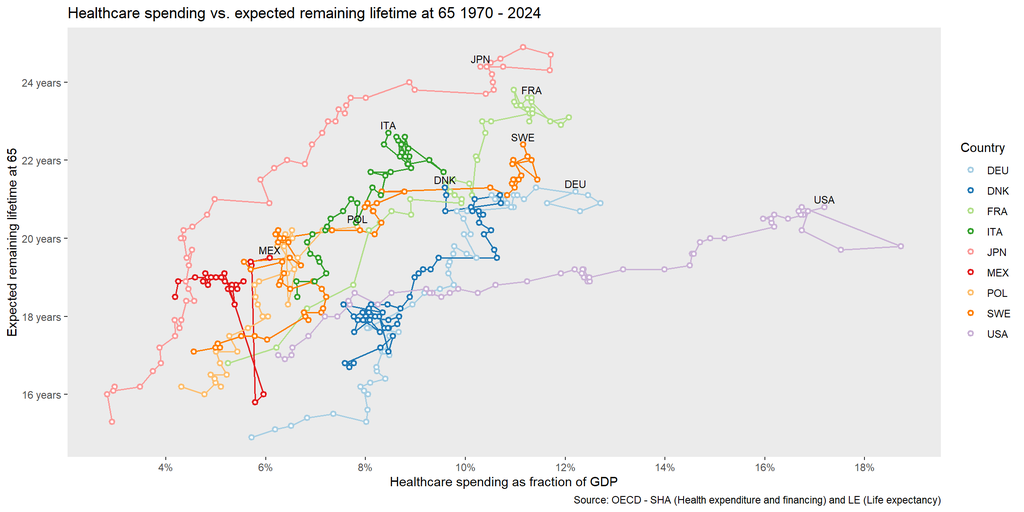

## Thanks for your attention